# Data wrangling report :Twitter Analysis

[figure not shown]

If you are a dog lover you must know this page `Weratedogs`. This is the community where those cuties's picture would be posted to rate. 10/10, 12/10, 15/10, etc . Actually the rate is not so important, this is a playground for us to share our cuties friends with story. What a lovely place for you to relax after hardworking hours. Let's dive into this page to understand more this friendly community.

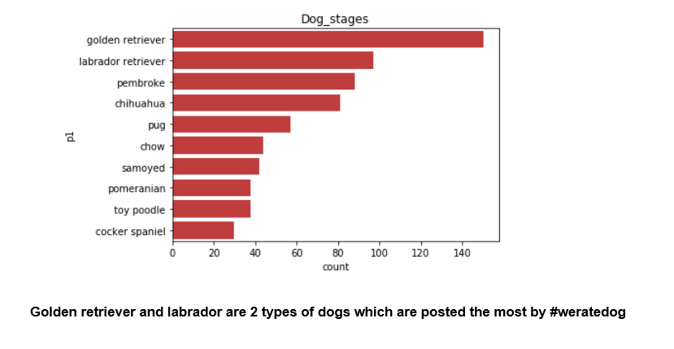

First of all, there are alot of breed but the most talked in tweeter are 2 types of dogs : Golden retriever and labrador.However they are not the ones who receive the highest rating , favorites and retweet. Those buddies are:

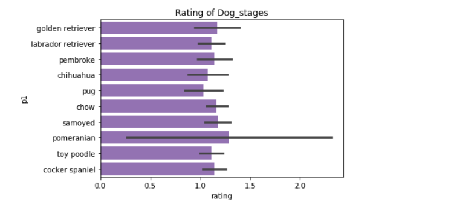

Pomeranian receives the best score and also the range of rating varies the most.Compared to the rating of "experts", the community love Samoyed more with more retweet(cocker spaniel ranked 2nd,next woudl be golden and labrador) and favorites(pembroke, golden , and labrador).

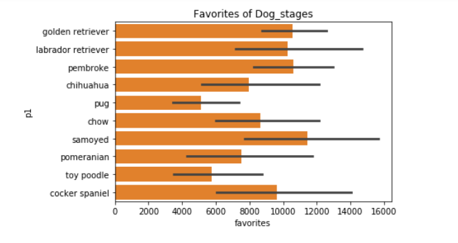

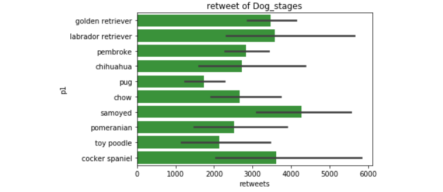

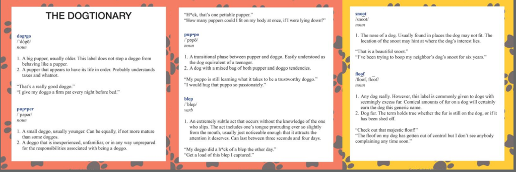

doggo: big dog ,pupper : small doggo, puppo: teenage dog, floofer: excessive hair

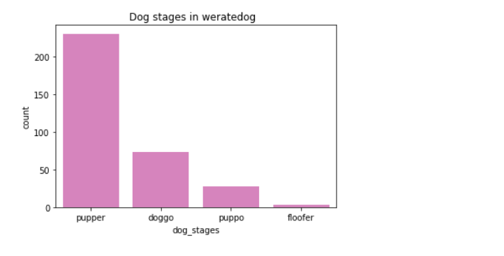

Most of dogs there are small dogs, there are alot of NA value . Haven't been counted here

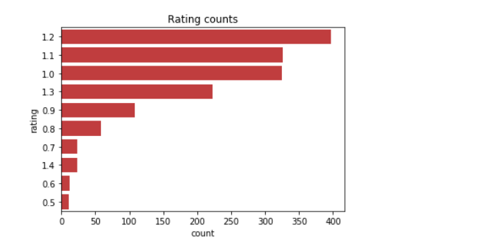

Because this community is not make for competition.so Scores are really generous for the puppies, most of the scores are more than 10. All pupies are cute, so it is hard of experts to rate them. There are also puppies who can get 75 scores out of 10 .

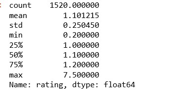

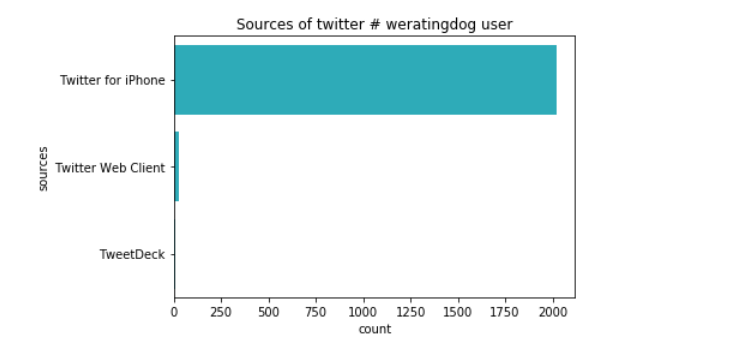

Most of people use phone to post their babies.

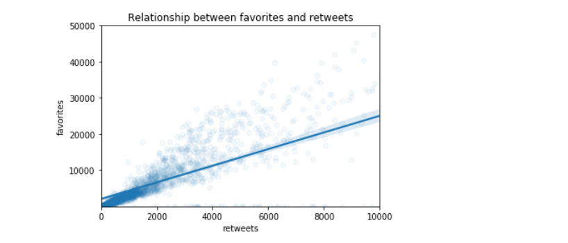

We also can see the strong relationship between retweet and favorites, If I dont remove extreme outliner , there would be more. These post at least receive more than 100 000 tweets through 2015-2017